# Estradiol & Progesterone Gene Expression Prediction

Sneha M. Chaturvedi, Emma Jones

Last updated 2026-09-04

| **Inputs** | `data/cache/pb_base.rds`, `doc/targeted/targeted_hormones.xlsx` |
| --- | --- |
| **Outputs** | Result CSVs and figures in `results/gene-hormone/estradiol_genes/` and `results/gene-hormone/progesterone_genes/` |
| **Upstream** | `prep_data.R` |
| **Downstream** | `targeted_gene_list_limma.qmd` |

## Goals

Identify genes whose pseudobulk expression is predicted by estradiol (E2) and progesterone (P4) concentration, by cell type. Both hormones are analyzed **sex-combined**: XX and XY samples are pooled, with Sex optionally included as an additive covariate.

**Four models tested per hormone:**

- **Base** — `~ hormone`
- **Base + Sex** — `~ hormone + Sex`
- **Base + Batch** — `~ hormone + batch1_frac`
- **Base + Sex + Batch** — `~ hormone + Sex + batch1_frac`

All four models use `analyze_hormone_combined()`. Samples from both sexes contribute to each cell type estimate regardless of whether Sex enters the formula.

## Set Up

- Load packages

  ```r
  knitr::opts_chunk$set(echo = TRUE)

  Packages <- c(
    "tidyverse", "Seurat", "Signac", "glue", "readxl", "cowplot",
    "edgeR", "limma", "patchwork", "svglite", "Matrix", "ggpubr"
  )
  lapply(Packages, library, character.only = TRUE)

  source("pseudobulk_functions.R")
  root <- find_project_root()

  set.seed(123)
  ```

- Load data

  ```r
  SSD_data <- readRDS(file.path(root, "data/cache/SSD_meta_umap.rds"))
  pb_base     <- readRDS(file.path(root, "data/cache/pb_base.rds"))
  targeted_comparison_raw <- read_xlsx(file.path(root, "doc/targeted/targeted_hormones.xlsx"))
  targeted_comparison_raw$E2 <- targeted_comparison_raw$`17B-E2 (ng/mL)`
  targeted_comparison_raw$TT <- targeted_comparison_raw$`TT (ng/mL)`
  targeted_comparison_raw$P4 <- targeted_comparison_raw$`P4 (ng/mL)`
  ```

- Configuration

  ```r
  celltype_col <- "celltype"
  sample_col <- "Sample"
  pb_sample_pattern <- "tissue\\d+"
  ```

## Outlier Removal

Samples with hormone > Q3 + 1.5 × IQR are excluded per hormone before pseudobulk construction.

```r
detect_outliers <- function(data, variable) {
  outlier_limit <- quantile(data[[variable]], 0.75, na.rm = TRUE) +
    1.5 * IQR(data[[variable]], na.rm = TRUE)
  data %>% dplyr::filter(.data[[variable]] <= outlier_limit)
}

targeted_comparison_filtered_E2 <- detect_outliers(targeted_comparison_raw, "E2")
targeted_comparison_filtered_P4 <- detect_outliers(targeted_comparison_raw, "P4")

cat(
  "E2 — before:", nrow(targeted_comparison_raw),
  "  after:", nrow(targeted_comparison_filtered_E2), "\n"
)
```

```
## E2 — before: 46   after: 41
```

```r
cat(
  "P4 — before:", nrow(targeted_comparison_raw),
  "  after:", nrow(targeted_comparison_filtered_P4), "\n"
)
```

```
## P4 — before: 46   after: 41
```

```r
cat("E2 range after filtering:      ",
    paste(round(range(targeted_comparison_filtered_E2$E2, na.rm = TRUE), 3),
          collapse = " – "), "ng/mL\n")
```

```
## E2 range after filtering:       0.03 – 3.266 ng/mL
```

```r
cat("P4 range after filtering:      ",
    paste(round(range(targeted_comparison_filtered_P4$P4, na.rm = TRUE), 3),
          collapse = " – "), "ng/mL\n")
```

```
## P4 range after filtering:       2.47 – 29.781 ng/mL
```

```r
outliers_E2 <- dplyr::anti_join(targeted_comparison_raw,
                                targeted_comparison_filtered_E2, by = "Sample")
outliers_P4 <- dplyr::anti_join(targeted_comparison_raw,
                                targeted_comparison_filtered_P4, by = "Sample")

cat("E2 outliers removed:",
    if (nrow(outliers_E2)) paste(outliers_E2$Sample, collapse = ", ") else "none", "\n")
```

```
## E2 outliers removed: 7, 17, 31, 33, 38
```

```r
cat("P4 outliers removed:",
    if (nrow(outliers_P4)) paste(outliers_P4$Sample, collapse = ", ") else "none", "\n")
```

```
## P4 outliers removed: 17, 31, 33, 35, 39
```

## Pseudobulk

Min 30 cells per (sample × cell type) for inclusion. `add_batch_fraction()` computes the fraction of batch1 cells per biological sample and joins it onto the pseudobulk metadata for each hormone.

```r
pb_E2 <- merge_hormone_metadata(
  pb_base, targeted_comparison_filtered_E2,
  pb_sample_pattern = pb_sample_pattern, min_cells = 30
) %>% add_batch_fraction(SSD_data)

pb_P4 <- merge_hormone_metadata(
  pb_base, targeted_comparison_filtered_P4,
  pb_sample_pattern = pb_sample_pattern, min_cells = 30
) %>% add_batch_fraction(SSD_data)

cat(
  "E2 pseudobulk samples:", nrow(pb_E2$metadata),
  "  NAs in batch1_frac:", sum(is.na(pb_E2$metadata$batch1_frac)), "\n"
)
```

```
## E2 pseudobulk samples: 421   NAs in batch1_frac: 0
```

```r
cat("E2 batch1_frac summary:\n")
```

```
## E2 batch1_frac summary:
```

```r
print(summary(pb_E2$metadata$batch1_frac))
```

```
##    Min. 1st Qu.  Median    Mean 3rd Qu.    Max.
##  0.0000  0.2711  0.4547  0.4319  0.5787  1.0000
```

```r
cat(
  "P4 pseudobulk samples:", nrow(pb_P4$metadata),
  "  NAs in batch1_frac:", sum(is.na(pb_P4$metadata$batch1_frac)), "\n"
)
```

```
## P4 pseudobulk samples: 418   NAs in batch1_frac: 0
```

```r
cat("P4 batch1_frac summary:\n")
```

```
## P4 batch1_frac summary:
```

```r
print(summary(pb_P4$metadata$batch1_frac))
```

```
##    Min. 1st Qu.  Median    Mean 3rd Qu.    Max.
##  0.0000  0.2413  0.4447  0.4279  0.5787  1.0000
```

## Models

| Model | Formula | Notes |
| --- | --- | --- |
| Base | `~ hormone` | Combined-sample estimate; no adjustment |
| Base + Sex | `~ hormone + Sex` | Controls for sex-linked expression differences |
| Base + Batch | `~ hormone + batch1_frac` | Batch1 fraction per sample (continuous); absorbs residual batch composition differences |
| Base + Sex + Batch | `~ hormone + Sex + batch1_frac` | Both adjustments |

## Estradiol

### Base

`~ E2` — sex-combined, no covariates.

```r
res_E2_base <- analyze_hormone_combined(
  pb_E2$counts, pb_E2$metadata,
  hormone = "E2", model = run_voom_lm, min_samples = 21
)
```

```
##
## Group: Astrocyte-Immature
## Initial number of samples: 24
## Min samples required (fixed floor): 21
## Genes passing manual filter: 17776
## Samples with non-zero hormone: 24
## Final sample size: 24
##
## Group: Cajal-Retzius cell
## Initial number of samples: 5
## Min samples required (fixed floor): 21
## Genes passing manual filter: 8807
## Samples with non-zero hormone: 5
## Group removed: insufficient non-zero hormone values 5
##
## Group: EN-IT-Immature
## Initial number of samples: 34
## Min samples required (fixed floor): 21
## Genes passing manual filter: 27542
## Samples with non-zero hormone: 34
## Final sample size: 34
##
## Group: EN-L4-IT
## Initial number of samples: 13
## Min samples required (fixed floor): 21
## Genes passing manual filter: 18271
## Samples with non-zero hormone: 13
## Group removed: insufficient non-zero hormone values 13
##
## Group: EN-L5_6-NP
## Initial number of samples: 16
## Min samples required (fixed floor): 21
## Genes passing manual filter: 17075
## Samples with non-zero hormone: 16
## Group removed: insufficient non-zero hormone values 16
##
## Group: EN-L5-IT
## Initial number of samples: 1
## Min samples required (fixed floor): 21
## Genes passing manual filter: 0
```

[output cut: 129 more lines]

```
## Samples with non-zero hormone: 14
## Group removed: insufficient non-zero hormone values 14
##
## Group: Unknown
## Initial number of samples: 3
## Min samples required (fixed floor): 21
## Genes passing manual filter: 6853
## Samples with non-zero hormone: 3
## Group removed: insufficient non-zero hormone values 3
##
## Group: Vascular
## Initial number of samples: 1
## Min samples required (fixed floor): 21
## Genes passing manual filter: 0
## Group removed: no genes passed the filter
```

```r
summary_E2_base <- summarize_sig_genes(res_E2_base$combined_results)

plot_top_genes_from_subsets(
  res_E2_base$by_group_data,
  output_dir = file.path(root, "results/gene-hormone/estradiol_genes/run_voom_lm"),
  hormone    = "E2",
  color_by   = "GW",
  single_fit = TRUE
)
```

```
## Number of groups to plot: 10
```

```
##  Plotting group: Astrocyte-Immature_combined
```

```
## - Significant genes (FDR < 0.1, |logFC| >= 0.25): 0
```

```
## No valid plots for group
```

```
##  Plotting group: EN-IT-Immature_combined
```

```
## - Significant genes (FDR < 0.1, |logFC| >= 0.25): 0
```

```
## No valid plots for group
```

```
##  Plotting group: EN-L6-IT_combined
```

```
## - Significant genes (FDR < 0.1, |logFC| >= 0.25): 0
```

```
## No valid plots for group
```

```
##  Plotting group: EN-L6b_combined
```

```
## - Significant genes (FDR < 0.1, |logFC| >= 0.25): 0
```

```
## No valid plots for group
```

```
##  Plotting group: EN-Newborn_combined
```

```
## - Significant genes (FDR < 0.1, |logFC| >= 0.25): 0
```

```
## No valid plots for group
```

```
##  Plotting group: EN-Non-IT-Immature_combined
```

```
## - Significant genes (FDR < 0.1, |logFC| >= 0.25): 0
```

```
## No valid plots for group
```

```
##  Plotting group: IN-CGE-Immature_combined
```

```
## - Significant genes (FDR < 0.1, |logFC| >= 0.25): 0
```

```
## No valid plots for group
```

```
##  Plotting group: IN-MGE-Immature_combined
```

```
## - Significant genes (FDR < 0.1, |logFC| >= 0.25): 0
```

```
## No valid plots for group
```

```
##  Plotting group: IN-MGE-SST_combined
```

```
## - Significant genes (FDR < 0.1, |logFC| >= 0.25): 0
```

```
## No valid plots for group
```

```
##  Plotting group: IPC-EN_combined
```

```
## - Significant genes (FDR < 0.1, |logFC| >= 0.25): 0
```

```
## No valid plots for group
```

```r
save_dual_format(
  plot_sig_gene_summary(summary_E2_base, "E2 — Base (~ E2)"),
  output_dir    = file.path(root, "results/gene-hormone/estradiol_genes/run_voom_lm"),
  filename_base = "E2_base_sig_gene_summary"
)
```

```
## Saved: E2_base_sig_gene_summary.png  +  svg/E2_base_sig_gene_summary.svg
```

```r
write_csv(
  res_E2_base$combined_results,
  file.path(root, "results/gene-hormone/estradiol_genes/run_voom_lm/E2_base_results.csv")
)
write_csv(
  summary_E2_base,
  file.path(root, "results/gene-hormone/estradiol_genes/run_voom_lm/E2_base_summary.csv")
)
```

#### Significant Genes

[figure not shown]

```r
plot_sig_gene_summary(summary_E2_base, "E2 — Base (~ E2)")
```

#### Top Results

```r
res_E2_base$combined_results %>%
  dplyr::arrange(adj.P.Val) %>%
  dplyr::select(gene, cell_type, sex, logFC, adj.P.Val) %>%
  head(10) %>%
  knitr::kable(digits = 4, caption = "Top 10 hits — E2 Base")
```

Top 10 hits — E2 Base

| gene | cell_type | sex | logFC | adj.P.Val |
| --- | --- | --- | --- | --- |
| ENSG00000286797 | IN-MGE-Immature | combined | 1.6297 | 0.1369 |
| FSIP2 | EN-IT-Immature | combined | 0.8567 | 0.2486 |
| ENSG00000251555 | IN-CGE-Immature | combined | 1.3664 | 0.2982 |
| DSCAM | IN-CGE-Immature | combined | 0.8055 | 0.2982 |
| TMEM202-AS1 | EN-Non-IT-Immature | combined | 0.8814 | 0.3661 |
| ENSG00000286797 | EN-Newborn | combined | 1.4422 | 0.3687 |
| ENSG00000286797 | IN-MGE-SST | combined | 1.8199 | 0.4381 |
| ENSG00000253636 | IN-MGE-SST | combined | -1.3224 | 0.4381 |
| MORN5 | IN-MGE-SST | combined | -1.1307 | 0.4381 |
| ENSG00000285700 | EN-Non-IT-Immature | combined | 0.9347 | 0.4567 |

### Base + Sex

`~ E2 + Sex`

```r
res_E2_sex <- analyze_hormone_combined(
  pb_E2$counts, pb_E2$metadata,
  hormone = "E2", model = run_voom_lm_sex, min_samples = 21
)
```

```
##
## Group: Astrocyte-Immature
## Initial number of samples: 24
## Min samples required (fixed floor): 21
## Genes passing manual filter: 17776
## Samples with non-zero hormone: 24
## Final sample size: 24
##
## Group: Cajal-Retzius cell
## Initial number of samples: 5
## Min samples required (fixed floor): 21
## Genes passing manual filter: 8807
## Samples with non-zero hormone: 5
## Group removed: insufficient non-zero hormone values 5
##
## Group: EN-IT-Immature
## Initial number of samples: 34
## Min samples required (fixed floor): 21
## Genes passing manual filter: 27542
## Samples with non-zero hormone: 34
## Final sample size: 34
##
## Group: EN-L4-IT
## Initial number of samples: 13
## Min samples required (fixed floor): 21
## Genes passing manual filter: 18271
## Samples with non-zero hormone: 13
## Group removed: insufficient non-zero hormone values 13
##
## Group: EN-L5_6-NP
## Initial number of samples: 16
## Min samples required (fixed floor): 21
## Genes passing manual filter: 17075
## Samples with non-zero hormone: 16
## Group removed: insufficient non-zero hormone values 16
##
## Group: EN-L5-IT
## Initial number of samples: 1
## Min samples required (fixed floor): 21
## Genes passing manual filter: 0
```

[output cut: 129 more lines]

```
## Samples with non-zero hormone: 14
## Group removed: insufficient non-zero hormone values 14
##
## Group: Unknown
## Initial number of samples: 3
## Min samples required (fixed floor): 21
## Genes passing manual filter: 6853
## Samples with non-zero hormone: 3
## Group removed: insufficient non-zero hormone values 3
##
## Group: Vascular
## Initial number of samples: 1
## Min samples required (fixed floor): 21
## Genes passing manual filter: 0
## Group removed: no genes passed the filter
```

```r
summary_E2_sex <- summarize_sig_genes(res_E2_sex$combined_results)

plot_top_genes_from_subsets(
  res_E2_sex$by_group_data,
  output_dir = file.path(root, "results/gene-hormone/estradiol_genes/run_voom_lm_sex"),
  hormone    = "E2",
  color_by   = "GW",
  single_fit = TRUE
)
```

```
## Number of groups to plot: 10
```

```
##  Plotting group: Astrocyte-Immature_combined
```

```
## - Significant genes (FDR < 0.1, |logFC| >= 0.25): 0
```

```
## No valid plots for group
```

```
##  Plotting group: EN-IT-Immature_combined
```

```
## - Significant genes (FDR < 0.1, |logFC| >= 0.25): 0
```

```
## No valid plots for group
```

```
##  Plotting group: EN-L6-IT_combined
```

```
## - Significant genes (FDR < 0.1, |logFC| >= 0.25): 0
```

```
## No valid plots for group
```

```
##  Plotting group: EN-L6b_combined
```

```
## - Significant genes (FDR < 0.1, |logFC| >= 0.25): 0
```

```
## No valid plots for group
```

```
##  Plotting group: EN-Newborn_combined
```

```
## - Significant genes (FDR < 0.1, |logFC| >= 0.25): 0
```

```
## No valid plots for group
```

```
##  Plotting group: EN-Non-IT-Immature_combined
```

```
## - Significant genes (FDR < 0.1, |logFC| >= 0.25): 0
```

```
## No valid plots for group
```

```
##  Plotting group: IN-CGE-Immature_combined
```

```
## - Significant genes (FDR < 0.1, |logFC| >= 0.25): 0
```

```
## No valid plots for group
```

```
##  Plotting group: IN-MGE-Immature_combined
```

```
## - Significant genes (FDR < 0.1, |logFC| >= 0.25): 0
```

```
## No valid plots for group
```

```
##  Plotting group: IN-MGE-SST_combined
```

```
## - Significant genes (FDR < 0.1, |logFC| >= 0.25): 0
```

```
## No valid plots for group
```

```
##  Plotting group: IPC-EN_combined
```

```
## - Significant genes (FDR < 0.1, |logFC| >= 0.25): 0
```

```
## No valid plots for group
```

```r
save_dual_format(
  plot_sig_gene_summary(summary_E2_sex, "E2 — Base + Sex (~ E2 + Sex)"),
  output_dir    = file.path(root, "results/gene-hormone/estradiol_genes/run_voom_lm_sex"),
  filename_base = "E2_sex_sig_gene_summary"
)
```

```
## Saved: E2_sex_sig_gene_summary.png  +  svg/E2_sex_sig_gene_summary.svg
```

```r
write_csv(
  res_E2_sex$combined_results,
  file.path(root, "results/gene-hormone/estradiol_genes/run_voom_lm_sex/E2_sex_results.csv")
)
write_csv(
  summary_E2_sex,
  file.path(root, "results/gene-hormone/estradiol_genes/run_voom_lm_sex/E2_sex_summary.csv")
)
```

#### Significant Genes

[figure not shown]

```r
plot_sig_gene_summary(summary_E2_sex, "E2 — Base + Sex (~ E2 + Sex)")
```

#### Top Results

```r
res_E2_sex$combined_results %>%
  dplyr::arrange(adj.P.Val) %>%
  dplyr::select(gene, cell_type, sex, logFC, adj.P.Val) %>%
  head(10) %>%
  knitr::kable(digits = 4, caption = "Top 10 hits — E2 Base + Sex")
```

Top 10 hits — E2 Base + Sex

| gene | cell_type | sex | logFC | adj.P.Val |
| --- | --- | --- | --- | --- |
| ENSG00000286797 | IN-MGE-Immature | combined | 1.6271 | 0.1054 |
| ENSG00000286797 | IN-MGE-SST | combined | 1.9058 | 0.1216 |
| TMEM202-AS1 | EN-Non-IT-Immature | combined | 0.8951 | 0.2507 |
| FSIP2 | EN-IT-Immature | combined | 0.8535 | 0.3045 |
| DSCAM | IN-CGE-Immature | combined | 0.8104 | 0.3290 |
| ENSG00000251555 | IN-CGE-Immature | combined | 1.3457 | 0.3963 |
| ENSG00000285700 | EN-Non-IT-Immature | combined | 0.9372 | 0.4383 |
| ENSG00000253636 | IN-MGE-SST | combined | -1.3170 | 0.4755 |
| MORN5 | IN-MGE-SST | combined | -1.1252 | 0.6006 |
| NRP1 | IN-CGE-Immature | combined | 1.0985 | 0.6701 |

### Base + Batch

`~ E2 + batch1_frac`

```r
res_E2_batch <- analyze_hormone_combined(
  pb_E2$counts, pb_E2$metadata,
  hormone = "E2", model = run_voom_lm_batch, min_samples = 21
)
```

```
##
## Group: Astrocyte-Immature
## Initial number of samples: 24
## Min samples required (fixed floor): 21
## Genes passing manual filter: 17776
## Samples with non-zero hormone: 24
## Final sample size: 24
##
## Group: Cajal-Retzius cell
## Initial number of samples: 5
## Min samples required (fixed floor): 21
## Genes passing manual filter: 8807
## Samples with non-zero hormone: 5
## Group removed: insufficient non-zero hormone values 5
##
## Group: EN-IT-Immature
## Initial number of samples: 34
## Min samples required (fixed floor): 21
## Genes passing manual filter: 27542
## Samples with non-zero hormone: 34
## Final sample size: 34
##
## Group: EN-L4-IT
## Initial number of samples: 13
## Min samples required (fixed floor): 21
## Genes passing manual filter: 18271
## Samples with non-zero hormone: 13
## Group removed: insufficient non-zero hormone values 13
##
## Group: EN-L5_6-NP
## Initial number of samples: 16
## Min samples required (fixed floor): 21
## Genes passing manual filter: 17075
## Samples with non-zero hormone: 16
## Group removed: insufficient non-zero hormone values 16
##
## Group: EN-L5-IT
## Initial number of samples: 1
## Min samples required (fixed floor): 21
## Genes passing manual filter: 0
```

[output cut: 129 more lines]

```
## Samples with non-zero hormone: 14
## Group removed: insufficient non-zero hormone values 14
##
## Group: Unknown
## Initial number of samples: 3
## Min samples required (fixed floor): 21
## Genes passing manual filter: 6853
## Samples with non-zero hormone: 3
## Group removed: insufficient non-zero hormone values 3
##
## Group: Vascular
## Initial number of samples: 1
## Min samples required (fixed floor): 21
## Genes passing manual filter: 0
## Group removed: no genes passed the filter
```

```r
summary_E2_batch <- summarize_sig_genes(res_E2_batch$combined_results)

plot_top_genes_from_subsets(
  res_E2_batch$by_group_data,
  output_dir = file.path(root, "results/gene-hormone/estradiol_genes/run_voom_lm_batch"),
  hormone    = "E2",
  color_by   = "GW",
  single_fit = TRUE
)
```

```
## Number of groups to plot: 10
```

```
##  Plotting group: Astrocyte-Immature_combined
```

```
## - Significant genes (FDR < 0.1, |logFC| >= 0.25): 0
```

```
## No valid plots for group
```

```
##  Plotting group: EN-IT-Immature_combined
```

```
## - Significant genes (FDR < 0.1, |logFC| >= 0.25): 0
```

```
## No valid plots for group
```

```
##  Plotting group: EN-L6-IT_combined
```

```
## - Significant genes (FDR < 0.1, |logFC| >= 0.25): 0
```

```
## No valid plots for group
```

```
##  Plotting group: EN-L6b_combined
```

```
## - Significant genes (FDR < 0.1, |logFC| >= 0.25): 0
```

```
## No valid plots for group
```

```
##  Plotting group: EN-Newborn_combined
```

```
## - Significant genes (FDR < 0.1, |logFC| >= 0.25): 0
```

```
## No valid plots for group
```

```
##  Plotting group: EN-Non-IT-Immature_combined
```

```
## - Significant genes (FDR < 0.1, |logFC| >= 0.25): 0
```

```
## No valid plots for group
```

```
##  Plotting group: IN-CGE-Immature_combined
```

```
## - Significant genes (FDR < 0.1, |logFC| >= 0.25): 0
```

```
## No valid plots for group
```

```
##  Plotting group: IN-MGE-Immature_combined
```

```
## - Significant genes (FDR < 0.1, |logFC| >= 0.25): 1
```

```
##     Plotting gene: ENSG00000286797 (adj. p-value: 0.0146)
```

```
## Saved: IN-MGE-Immature_combined_top_genes.png  +  svg/IN-MGE-Immature_combined_top_genes.svg
##   Saved plot for IN-MGE-Immature_combined
##  Plotting group: IN-MGE-SST_combined
## - Significant genes (FDR < 0.1, |logFC| >= 0.25): 0
## No valid plots for group
##  Plotting group: IPC-EN_combined
## - Significant genes (FDR < 0.1, |logFC| >= 0.25): 0
## No valid plots for group
```

```r
save_dual_format(
  plot_sig_gene_summary(summary_E2_batch, "E2 — Base + Batch (~ E2 + batch1_frac)"),
  output_dir    = file.path(root, "results/gene-hormone/estradiol_genes/run_voom_lm_batch"),
  filename_base = "E2_batch_sig_gene_summary"
)
```

```
## Saved: E2_batch_sig_gene_summary.png  +  svg/E2_batch_sig_gene_summary.svg
```

```r
write_csv(
  res_E2_batch$combined_results,
  file.path(root, "results/gene-hormone/estradiol_genes/run_voom_lm_batch/E2_batch_results.csv")
)
write_csv(
  summary_E2_batch,
  file.path(root, "results/gene-hormone/estradiol_genes/run_voom_lm_batch/E2_batch_summary.csv")
)
```

#### Significant Genes

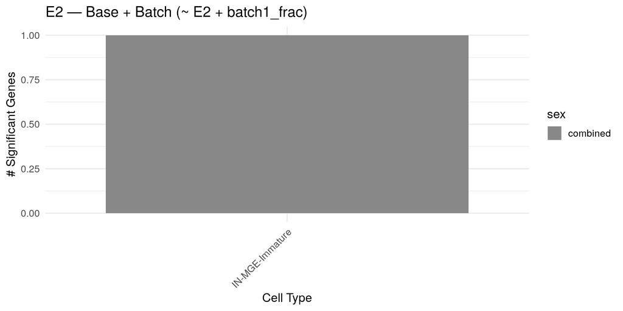

```r
plot_sig_gene_summary(summary_E2_batch, "E2 — Base + Batch (~ E2 + batch1_frac)")
```

#### Top Results

```r
res_E2_batch$combined_results %>%
  dplyr::arrange(adj.P.Val) %>%
  dplyr::select(gene, cell_type, sex, logFC, adj.P.Val) %>%
  head(10) %>%
  knitr::kable(digits = 4, caption = "Top 10 hits — E2 Base + Batch")
```

Top 10 hits — E2 Base + Batch

| gene | cell_type | sex | logFC | adj.P.Val |
| --- | --- | --- | --- | --- |
| ENSG00000286797 | IN-MGE-Immature | combined | 1.7223 | 0.0146 |
| DSCAM | IN-CGE-Immature | combined | 0.8034 | 0.3210 |
| ENSG00000251555 | IN-CGE-Immature | combined | 1.3651 | 0.3860 |
| TMEM202-AS1 | EN-Non-IT-Immature | combined | 0.8959 | 0.4306 |
| FSIP2 | EN-IT-Immature | combined | 0.8422 | 0.5432 |
| ENSG00000253636 | IN-MGE-SST | combined | -1.3535 | 0.5827 |
| ENSG00000286797 | IN-MGE-SST | combined | 1.8186 | 0.5831 |
| MORN5 | IN-MGE-SST | combined | -1.1271 | 0.5831 |
| PLXDC2 | IN-MGE-SST | combined | -0.9322 | 0.5831 |
| GAS2 | IN-MGE-SST | combined | -0.6197 | 0.6312 |

### Base + Sex + Batch

`~ E2 + Sex + batch1_frac`

```r
res_E2_sex_batch <- analyze_hormone_combined(
  pb_E2$counts, pb_E2$metadata,
  hormone = "E2", model = run_voom_lm_sex_batch, min_samples = 21
)
```

```
##
## Group: Astrocyte-Immature
## Initial number of samples: 24
## Min samples required (fixed floor): 21
## Genes passing manual filter: 17776
## Samples with non-zero hormone: 24
## Final sample size: 24
##
## Group: Cajal-Retzius cell
## Initial number of samples: 5
## Min samples required (fixed floor): 21
## Genes passing manual filter: 8807
## Samples with non-zero hormone: 5
## Group removed: insufficient non-zero hormone values 5
##
## Group: EN-IT-Immature
## Initial number of samples: 34
## Min samples required (fixed floor): 21
## Genes passing manual filter: 27542
## Samples with non-zero hormone: 34
## Final sample size: 34
##
## Group: EN-L4-IT
## Initial number of samples: 13
## Min samples required (fixed floor): 21
## Genes passing manual filter: 18271
## Samples with non-zero hormone: 13
## Group removed: insufficient non-zero hormone values 13
##
## Group: EN-L5_6-NP
## Initial number of samples: 16
## Min samples required (fixed floor): 21
## Genes passing manual filter: 17075
## Samples with non-zero hormone: 16
## Group removed: insufficient non-zero hormone values 16
##
## Group: EN-L5-IT
## Initial number of samples: 1
## Min samples required (fixed floor): 21
## Genes passing manual filter: 0
```

[output cut: 129 more lines]

```
## Samples with non-zero hormone: 14
## Group removed: insufficient non-zero hormone values 14
##
## Group: Unknown
## Initial number of samples: 3
## Min samples required (fixed floor): 21
## Genes passing manual filter: 6853
## Samples with non-zero hormone: 3
## Group removed: insufficient non-zero hormone values 3
##
## Group: Vascular
## Initial number of samples: 1
## Min samples required (fixed floor): 21
## Genes passing manual filter: 0
## Group removed: no genes passed the filter
```

```r
summary_E2_sex_batch <- summarize_sig_genes(res_E2_sex_batch$combined_results)

plot_top_genes_from_subsets(
  res_E2_sex_batch$by_group_data,
  output_dir = file.path(root, "results/gene-hormone/estradiol_genes/run_voom_lm_sex_batch"),
  hormone    = "E2",
  color_by   = "GW",
  single_fit = TRUE
)
```

```
## Number of groups to plot: 10
```

```
##  Plotting group: Astrocyte-Immature_combined
```

```
## - Significant genes (FDR < 0.1, |logFC| >= 0.25): 0
```

```
## No valid plots for group
```

```
##  Plotting group: EN-IT-Immature_combined
```

```
## - Significant genes (FDR < 0.1, |logFC| >= 0.25): 0
```

```
## No valid plots for group
```

```
##  Plotting group: EN-L6-IT_combined
```

```
## - Significant genes (FDR < 0.1, |logFC| >= 0.25): 0
```

```
## No valid plots for group
```

```
##  Plotting group: EN-L6b_combined
```

```
## - Significant genes (FDR < 0.1, |logFC| >= 0.25): 0
```

```
## No valid plots for group
```

```
##  Plotting group: EN-Newborn_combined
```

```
## - Significant genes (FDR < 0.1, |logFC| >= 0.25): 0
```

```
## No valid plots for group
```

```
##  Plotting group: EN-Non-IT-Immature_combined
```

```
## - Significant genes (FDR < 0.1, |logFC| >= 0.25): 0
```

```
## No valid plots for group
```

```
##  Plotting group: IN-CGE-Immature_combined
```

```
## - Significant genes (FDR < 0.1, |logFC| >= 0.25): 0
```

```
## No valid plots for group
```

```
##  Plotting group: IN-MGE-Immature_combined
```

```
## - Significant genes (FDR < 0.1, |logFC| >= 0.25): 1
```

```
##     Plotting gene: ENSG00000286797 (adj. p-value: 0.0155)
```

```
## Saved: IN-MGE-Immature_combined_top_genes.png  +  svg/IN-MGE-Immature_combined_top_genes.svg
##   Saved plot for IN-MGE-Immature_combined
##  Plotting group: IN-MGE-SST_combined
## - Significant genes (FDR < 0.1, |logFC| >= 0.25): 0
## No valid plots for group
##  Plotting group: IPC-EN_combined
## - Significant genes (FDR < 0.1, |logFC| >= 0.25): 0
## No valid plots for group
```

```r
save_dual_format(
  plot_sig_gene_summary(
    summary_E2_sex_batch,
    "E2 — Base + Sex + Batch (~ E2 + Sex + batch1_frac)"
  ),
  output_dir = file.path(root, "results/gene-hormone/estradiol_genes/run_voom_lm_sex_batch"),
  filename_base = "E2_sex_batch_sig_gene_summary"
)
```

```
## Saved: E2_sex_batch_sig_gene_summary.png  +  svg/E2_sex_batch_sig_gene_summary.svg
```

```r
write_csv(
  res_E2_sex_batch$combined_results,
  file.path(root, "results/gene-hormone/estradiol_genes/run_voom_lm_sex_batch/E2_sex_batch_results.csv")
)
write_csv(
  summary_E2_sex_batch,
  file.path(root, "results/gene-hormone/estradiol_genes/run_voom_lm_sex_batch/E2_sex_batch_summary.csv")
)
```

#### Significant Genes

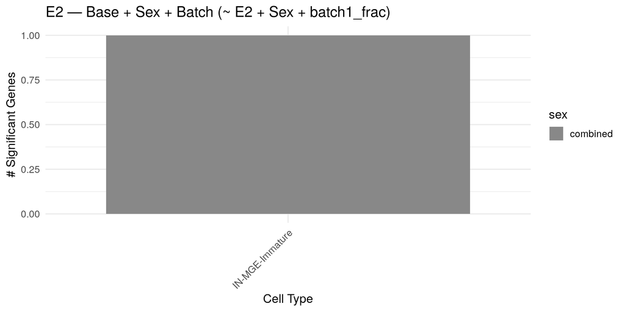

```r
plot_sig_gene_summary(
  summary_E2_sex_batch,
  "E2 — Base + Sex + Batch (~ E2 + Sex + batch1_frac)"
)
```

#### Top Results

```r
res_E2_sex_batch$combined_results %>%
  dplyr::arrange(adj.P.Val) %>%
  dplyr::select(gene, cell_type, sex, logFC, adj.P.Val) %>%
  head(10) %>%
  knitr::kable(digits = 4, caption = "Top 10 hits — E2 Base + Sex + Batch")
```

Top 10 hits — E2 Base + Sex + Batch

| gene | cell_type | sex | logFC | adj.P.Val |
| --- | --- | --- | --- | --- |
| ENSG00000286797 | IN-MGE-Immature | combined | 1.6991 | 0.0155 |
| DSCAM | IN-CGE-Immature | combined | 0.8035 | 0.1861 |
| TMEM202-AS1 | EN-Non-IT-Immature | combined | 0.9132 | 0.2708 |
| ENSG00000286797 | IN-MGE-SST | combined | 1.9040 | 0.3011 |
| ENSG00000253636 | IN-MGE-SST | combined | -1.3464 | 0.4093 |
| PCSK5 | EN-L6-IT | combined | -0.6388 | 0.4671 |
| ENSG00000251555 | IN-CGE-Immature | combined | 1.3454 | 0.4776 |
| NRP1 | IN-CGE-Immature | combined | 1.0664 | 0.5158 |
| EPHX1 | IN-CGE-Immature | combined | 1.0575 | 0.5295 |
| PDZRN3 | IN-CGE-Immature | combined | -0.3385 | 0.5295 |

## Progesterone

### Base

`~ P4` — sex-combined, no covariates.

```r
res_P4_base <- analyze_hormone_combined(
  pb_P4$counts, pb_P4$metadata,
  hormone = "P4", model = run_voom_lm, min_samples = 21
)
```

```
##
## Group: Astrocyte-Immature
## Initial number of samples: 24
## Min samples required (fixed floor): 21
## Genes passing manual filter: 18064
## Samples with non-zero hormone: 24
## Final sample size: 24
##
## Group: Cajal-Retzius cell
## Initial number of samples: 6
## Min samples required (fixed floor): 21
## Genes passing manual filter: 10810
## Samples with non-zero hormone: 6
## Group removed: insufficient non-zero hormone values 6
##
## Group: EN-IT-Immature
## Initial number of samples: 34
## Min samples required (fixed floor): 21
## Genes passing manual filter: 27537
## Samples with non-zero hormone: 34
## Final sample size: 34
##
## Group: EN-L4-IT
## Initial number of samples: 12
## Min samples required (fixed floor): 21
## Genes passing manual filter: 17177
## Samples with non-zero hormone: 12
## Group removed: insufficient non-zero hormone values 12
##
## Group: EN-L5_6-NP
## Initial number of samples: 17
## Min samples required (fixed floor): 21
## Genes passing manual filter: 17514
## Samples with non-zero hormone: 17
## Group removed: insufficient non-zero hormone values 17
##
## Group: EN-L5-IT
## Initial number of samples: 1
## Min samples required (fixed floor): 21
## Genes passing manual filter: 0
```

[output cut: 129 more lines]

```
## Samples with non-zero hormone: 13
## Group removed: insufficient non-zero hormone values 13
##
## Group: Unknown
## Initial number of samples: 3
## Min samples required (fixed floor): 21
## Genes passing manual filter: 6853
## Samples with non-zero hormone: 3
## Group removed: insufficient non-zero hormone values 3
##
## Group: Vascular
## Initial number of samples: 1
## Min samples required (fixed floor): 21
## Genes passing manual filter: 0
## Group removed: no genes passed the filter
```

```r
summary_P4_base <- summarize_sig_genes(res_P4_base$combined_results)

plot_top_genes_from_subsets(
  res_P4_base$by_group_data,
  output_dir = file.path(root, "results/gene-hormone/progesterone_genes/run_voom_lm"),
  hormone    = "P4",
  color_by   = "GW",
  single_fit = TRUE
)
```

```
## Number of groups to plot: 10
```

```
##  Plotting group: Astrocyte-Immature_combined
```

```
## - Significant genes (FDR < 0.1, |logFC| >= 0.25): 0
```

```
## No valid plots for group
```

```
##  Plotting group: EN-IT-Immature_combined
```

```
## - Significant genes (FDR < 0.1, |logFC| >= 0.25): 0
```

```
## No valid plots for group
```

```
##  Plotting group: EN-L6-IT_combined
```

```
## - Significant genes (FDR < 0.1, |logFC| >= 0.25): 0
```

```
## No valid plots for group
```

```
##  Plotting group: EN-L6b_combined
```

```
## - Significant genes (FDR < 0.1, |logFC| >= 0.25): 0
```

```
## No valid plots for group
```

```
##  Plotting group: EN-Newborn_combined
```

```
## - Significant genes (FDR < 0.1, |logFC| >= 0.25): 0
```

```
## No valid plots for group
```

```
##  Plotting group: EN-Non-IT-Immature_combined
```

```
## - Significant genes (FDR < 0.1, |logFC| >= 0.25): 0
```

```
## No valid plots for group
```

```
##  Plotting group: IN-CGE-Immature_combined
```

```
## - Significant genes (FDR < 0.1, |logFC| >= 0.25): 0
```

```
## No valid plots for group
```

```
##  Plotting group: IN-MGE-Immature_combined
```

```
## - Significant genes (FDR < 0.1, |logFC| >= 0.25): 0
```

```
## No valid plots for group
```

```
##  Plotting group: IN-MGE-SST_combined
```

```
## - Significant genes (FDR < 0.1, |logFC| >= 0.25): 0
```

```
## No valid plots for group
```

```
##  Plotting group: IPC-EN_combined
```

```
## - Significant genes (FDR < 0.1, |logFC| >= 0.25): 0
```

```
## No valid plots for group
```

```r
save_dual_format(
  plot_sig_gene_summary(summary_P4_base, "P4 — Base (~ P4)"),
  output_dir    = file.path(root, "results/gene-hormone/progesterone_genes/run_voom_lm"),
  filename_base = "P4_base_sig_gene_summary"
)
```

```
## Saved: P4_base_sig_gene_summary.png  +  svg/P4_base_sig_gene_summary.svg
```

```r
write_csv(
  res_P4_base$combined_results,
  file.path(root, "results/gene-hormone/progesterone_genes/run_voom_lm/P4_base_results.csv")
)
write_csv(
  summary_P4_base,
  file.path(root, "results/gene-hormone/progesterone_genes/run_voom_lm/P4_base_summary.csv")
)
```

#### Significant Genes

[figure not shown]

```r
plot_sig_gene_summary(summary_P4_base, "P4 — Base (~ P4)")
```

#### Top Results

```r
res_P4_base$combined_results %>%
  dplyr::arrange(adj.P.Val) %>%
  dplyr::select(gene, cell_type, sex, logFC, adj.P.Val) %>%
  head(10) %>%
  knitr::kable(digits = 4, caption = "Top 10 hits — P4 Base")
```

Top 10 hits — P4 Base

| gene | cell_type | sex | logFC | adj.P.Val |
| --- | --- | --- | --- | --- |
| ENSG00000248242 | EN-L6b | combined | 0.1400 | 0.0000 |
| CBR3 | EN-IT-Immature | combined | -0.1275 | 0.0002 |
| CAMKMT | EN-L6b | combined | 0.0549 | 0.0012 |
| PTPN18 | EN-L6b | combined | -0.0574 | 0.0012 |
| CDH12 | EN-L6b | combined | 0.0974 | 0.0012 |
| HULC | EN-L6b | combined | 0.0413 | 0.0012 |
| JARID2 | EN-L6b | combined | 0.0416 | 0.0012 |
| DGKB | EN-L6b | combined | 0.2058 | 0.0012 |
| ADRA2A | EN-L6b | combined | -0.1401 | 0.0012 |
| GABRB3 | EN-L6b | combined | 0.0300 | 0.0012 |

### Base + Sex

`~ P4 + Sex`

```r
res_P4_sex <- analyze_hormone_combined(
  pb_P4$counts, pb_P4$metadata,
  hormone = "P4", model = run_voom_lm_sex, min_samples = 21
)
```

```
##
## Group: Astrocyte-Immature
## Initial number of samples: 24
## Min samples required (fixed floor): 21
## Genes passing manual filter: 18064
## Samples with non-zero hormone: 24
## Final sample size: 24
##
## Group: Cajal-Retzius cell
## Initial number of samples: 6
## Min samples required (fixed floor): 21
## Genes passing manual filter: 10810
## Samples with non-zero hormone: 6
## Group removed: insufficient non-zero hormone values 6
##
## Group: EN-IT-Immature
## Initial number of samples: 34
## Min samples required (fixed floor): 21
## Genes passing manual filter: 27537
## Samples with non-zero hormone: 34
## Final sample size: 34
##
## Group: EN-L4-IT
## Initial number of samples: 12
## Min samples required (fixed floor): 21
## Genes passing manual filter: 17177
## Samples with non-zero hormone: 12
## Group removed: insufficient non-zero hormone values 12
##
## Group: EN-L5_6-NP
## Initial number of samples: 17
## Min samples required (fixed floor): 21
## Genes passing manual filter: 17514
## Samples with non-zero hormone: 17
## Group removed: insufficient non-zero hormone values 17
##
## Group: EN-L5-IT
## Initial number of samples: 1
## Min samples required (fixed floor): 21
## Genes passing manual filter: 0
```

[output cut: 129 more lines]

```
## Samples with non-zero hormone: 13
## Group removed: insufficient non-zero hormone values 13
##
## Group: Unknown
## Initial number of samples: 3
## Min samples required (fixed floor): 21
## Genes passing manual filter: 6853
## Samples with non-zero hormone: 3
## Group removed: insufficient non-zero hormone values 3
##
## Group: Vascular
## Initial number of samples: 1
## Min samples required (fixed floor): 21
## Genes passing manual filter: 0
## Group removed: no genes passed the filter
```

```r
summary_P4_sex <- summarize_sig_genes(res_P4_sex$combined_results)

plot_top_genes_from_subsets(
  res_P4_sex$by_group_data,
  output_dir = file.path(root, "results/gene-hormone/progesterone_genes/run_voom_lm_sex"),
  hormone    = "P4",
  color_by   = "GW",
  single_fit = TRUE
)
```

```
## Number of groups to plot: 10
```

```
##  Plotting group: Astrocyte-Immature_combined
```

```
## - Significant genes (FDR < 0.1, |logFC| >= 0.25): 0
```

```
## No valid plots for group
```

```
##  Plotting group: EN-IT-Immature_combined
```

```
## - Significant genes (FDR < 0.1, |logFC| >= 0.25): 0
```

```
## No valid plots for group
```

```
##  Plotting group: EN-L6-IT_combined
```

```
## - Significant genes (FDR < 0.1, |logFC| >= 0.25): 0
```

```
## No valid plots for group
```

```
##  Plotting group: EN-L6b_combined
```

```
## - Significant genes (FDR < 0.1, |logFC| >= 0.25): 0
```

```
## No valid plots for group
```

```
##  Plotting group: EN-Newborn_combined
```

```
## - Significant genes (FDR < 0.1, |logFC| >= 0.25): 0
```

```
## No valid plots for group
```

```
##  Plotting group: EN-Non-IT-Immature_combined
```

```
## - Significant genes (FDR < 0.1, |logFC| >= 0.25): 0
```

```
## No valid plots for group
```

```
##  Plotting group: IN-CGE-Immature_combined
```

```
## - Significant genes (FDR < 0.1, |logFC| >= 0.25): 0
```

```
## No valid plots for group
```

```
##  Plotting group: IN-MGE-Immature_combined
```

```
## - Significant genes (FDR < 0.1, |logFC| >= 0.25): 0
```

```
## No valid plots for group
```

```
##  Plotting group: IN-MGE-SST_combined
```

```
## - Significant genes (FDR < 0.1, |logFC| >= 0.25): 0
```

```
## No valid plots for group
```

```
##  Plotting group: IPC-EN_combined
```

```
## - Significant genes (FDR < 0.1, |logFC| >= 0.25): 0
```

```
## No valid plots for group
```

```r
save_dual_format(
  plot_sig_gene_summary(summary_P4_sex, "P4 — Base + Sex (~ P4 + Sex)"),
  output_dir    = file.path(root, "results/gene-hormone/progesterone_genes/run_voom_lm_sex"),
  filename_base = "P4_sex_sig_gene_summary"
)
```

```
## Saved: P4_sex_sig_gene_summary.png  +  svg/P4_sex_sig_gene_summary.svg
```

```r
write_csv(
  res_P4_sex$combined_results,
  file.path(root, "results/gene-hormone/progesterone_genes/run_voom_lm_sex/P4_sex_results.csv")
)
write_csv(
  summary_P4_sex,
  file.path(root, "results/gene-hormone/progesterone_genes/run_voom_lm_sex/P4_sex_summary.csv")
)
```

#### Significant Genes

[figure not shown]

```r
plot_sig_gene_summary(summary_P4_sex, "P4 — Base + Sex (~ P4 + Sex)")
```

#### Top Results

```r
res_P4_sex$combined_results %>%
  dplyr::arrange(adj.P.Val) %>%
  dplyr::select(gene, cell_type, sex, logFC, adj.P.Val) %>%
  head(10) %>%
  knitr::kable(digits = 4, caption = "Top 10 hits — P4 Base + Sex")
```

Top 10 hits — P4 Base + Sex

| gene | cell_type | sex | logFC | adj.P.Val |
| --- | --- | --- | --- | --- |
| CBR3 | EN-IT-Immature | combined | -0.1278 | 0.0001 |
| ENSG00000248242 | EN-L6b | combined | 0.1391 | 0.0002 |
| ADRA2A | EN-L6b | combined | -0.1411 | 0.0026 |
| B3GALT2 | EN-L6b | combined | -0.0636 | 0.0028 |
| CAMKMT | EN-L6b | combined | 0.0513 | 0.0028 |
| PTPN18 | EN-L6b | combined | -0.0564 | 0.0028 |
| NXPH2 | EN-L6b | combined | -0.1345 | 0.0028 |
| GBX2-AS1 | EN-L6b | combined | 0.1092 | 0.0028 |
| CCK | EN-L6b | combined | -0.1472 | 0.0028 |
| NCAPG | EN-L6b | combined | -0.0770 | 0.0028 |

### Base + Batch

`~ P4 + batch1_frac`

```r
res_P4_batch <- analyze_hormone_combined(
  pb_P4$counts, pb_P4$metadata,
  hormone = "P4", model = run_voom_lm_batch, min_samples = 21
)
```

```
##
## Group: Astrocyte-Immature
## Initial number of samples: 24
## Min samples required (fixed floor): 21
## Genes passing manual filter: 18064
## Samples with non-zero hormone: 24
## Final sample size: 24
##
## Group: Cajal-Retzius cell
## Initial number of samples: 6
## Min samples required (fixed floor): 21
## Genes passing manual filter: 10810
## Samples with non-zero hormone: 6
## Group removed: insufficient non-zero hormone values 6
##
## Group: EN-IT-Immature
## Initial number of samples: 34
## Min samples required (fixed floor): 21
## Genes passing manual filter: 27537
## Samples with non-zero hormone: 34
## Final sample size: 34
##
## Group: EN-L4-IT
## Initial number of samples: 12
## Min samples required (fixed floor): 21
## Genes passing manual filter: 17177
## Samples with non-zero hormone: 12
## Group removed: insufficient non-zero hormone values 12
##
## Group: EN-L5_6-NP
## Initial number of samples: 17
## Min samples required (fixed floor): 21
## Genes passing manual filter: 17514
## Samples with non-zero hormone: 17
## Group removed: insufficient non-zero hormone values 17
##
## Group: EN-L5-IT
## Initial number of samples: 1
## Min samples required (fixed floor): 21
## Genes passing manual filter: 0
```

[output cut: 129 more lines]

```
## Samples with non-zero hormone: 13
## Group removed: insufficient non-zero hormone values 13
##
## Group: Unknown
## Initial number of samples: 3
## Min samples required (fixed floor): 21
## Genes passing manual filter: 6853
## Samples with non-zero hormone: 3
## Group removed: insufficient non-zero hormone values 3
##
## Group: Vascular
## Initial number of samples: 1
## Min samples required (fixed floor): 21
## Genes passing manual filter: 0
## Group removed: no genes passed the filter
```

```r
summary_P4_batch <- summarize_sig_genes(res_P4_batch$combined_results)

plot_top_genes_from_subsets(
  res_P4_batch$by_group_data,
  output_dir = file.path(root, "results/gene-hormone/progesterone_genes/run_voom_lm_batch"),
  hormone    = "P4",
  color_by   = "GW",
  single_fit = TRUE
)
```

```
## Number of groups to plot: 10
```

```
##  Plotting group: Astrocyte-Immature_combined
```

```
## - Significant genes (FDR < 0.1, |logFC| >= 0.25): 0
```

```
## No valid plots for group
```

```
##  Plotting group: EN-IT-Immature_combined
```

```
## - Significant genes (FDR < 0.1, |logFC| >= 0.25): 0
```

```
## No valid plots for group
```

```
##  Plotting group: EN-L6-IT_combined
```

```
## - Significant genes (FDR < 0.1, |logFC| >= 0.25): 0
```

```
## No valid plots for group
```

```
##  Plotting group: EN-L6b_combined
```

```
## - Significant genes (FDR < 0.1, |logFC| >= 0.25): 0
```

```
## No valid plots for group
```

```
##  Plotting group: EN-Newborn_combined
```

```
## - Significant genes (FDR < 0.1, |logFC| >= 0.25): 0
```

```
## No valid plots for group
```

```
##  Plotting group: EN-Non-IT-Immature_combined
```

```
## - Significant genes (FDR < 0.1, |logFC| >= 0.25): 0
```

```
## No valid plots for group
```

```
##  Plotting group: IN-CGE-Immature_combined
```

```
## - Significant genes (FDR < 0.1, |logFC| >= 0.25): 0
```

```
## No valid plots for group
```

```
##  Plotting group: IN-MGE-Immature_combined
```

```
## - Significant genes (FDR < 0.1, |logFC| >= 0.25): 0
```

```
## No valid plots for group
```

```
##  Plotting group: IN-MGE-SST_combined
```

```
## - Significant genes (FDR < 0.1, |logFC| >= 0.25): 0
```

```
## No valid plots for group
```

```
##  Plotting group: IPC-EN_combined
```

```
## - Significant genes (FDR < 0.1, |logFC| >= 0.25): 0
```

```
## No valid plots for group
```

```r
save_dual_format(
  plot_sig_gene_summary(summary_P4_batch, "P4 — Base + Batch (~ P4 + batch1_frac)"),
  output_dir    = file.path(root, "results/gene-hormone/progesterone_genes/run_voom_lm_batch"),
  filename_base = "P4_batch_sig_gene_summary"
)
```

```
## Saved: P4_batch_sig_gene_summary.png  +  svg/P4_batch_sig_gene_summary.svg
```

```r
write_csv(
  res_P4_batch$combined_results,
  file.path(root, "results/gene-hormone/progesterone_genes/run_voom_lm_batch/P4_batch_results.csv")
)
write_csv(
  summary_P4_batch,
  file.path(root, "results/gene-hormone/progesterone_genes/run_voom_lm_batch/P4_batch_summary.csv")
)
```

#### Significant Genes

[figure not shown]

```r
plot_sig_gene_summary(summary_P4_batch, "P4 — Base + Batch (~ P4 + batch1_frac)")
```

#### Top Results

```r
res_P4_batch$combined_results %>%
  dplyr::arrange(adj.P.Val) %>%
  dplyr::select(gene, cell_type, sex, logFC, adj.P.Val) %>%
  head(10) %>%
  knitr::kable(digits = 4, caption = "Top 10 hits — P4 Base + Batch")
```

Top 10 hits — P4 Base + Batch

| gene | cell_type | sex | logFC | adj.P.Val |
| --- | --- | --- | --- | --- |
| ENSG00000248242 | EN-L6b | combined | 0.1420 | 0.0000 |
| DGKB | EN-L6b | combined | 0.2253 | 0.0001 |
| NXPH2 | EN-L6b | combined | -0.1534 | 0.0001 |
| CBR3 | EN-IT-Immature | combined | -0.1282 | 0.0004 |
| CDH8 | EN-L6b | combined | 0.1672 | 0.0010 |
| CAMKMT | EN-L6b | combined | 0.0578 | 0.0011 |
| CDH12 | EN-L6b | combined | 0.1004 | 0.0011 |
| ADRA2A | EN-L6b | combined | -0.1419 | 0.0011 |
| DISC1 | EN-L6b | combined | 0.0998 | 0.0017 |
| TMEM178A | EN-L6b | combined | -0.0704 | 0.0017 |

### Base + Sex + Batch

`~ P4 + Sex + batch1_frac`

```r
res_P4_sex_batch <- analyze_hormone_combined(
  pb_P4$counts, pb_P4$metadata,
  hormone = "P4", model = run_voom_lm_sex_batch, min_samples = 21
)
```

```
##
## Group: Astrocyte-Immature
## Initial number of samples: 24
## Min samples required (fixed floor): 21
## Genes passing manual filter: 18064
## Samples with non-zero hormone: 24
## Final sample size: 24
##
## Group: Cajal-Retzius cell
## Initial number of samples: 6
## Min samples required (fixed floor): 21
## Genes passing manual filter: 10810
## Samples with non-zero hormone: 6
## Group removed: insufficient non-zero hormone values 6
##
## Group: EN-IT-Immature
## Initial number of samples: 34
## Min samples required (fixed floor): 21
## Genes passing manual filter: 27537
## Samples with non-zero hormone: 34
## Final sample size: 34
##
## Group: EN-L4-IT
## Initial number of samples: 12
## Min samples required (fixed floor): 21
## Genes passing manual filter: 17177
## Samples with non-zero hormone: 12
## Group removed: insufficient non-zero hormone values 12
##
## Group: EN-L5_6-NP
## Initial number of samples: 17
## Min samples required (fixed floor): 21
## Genes passing manual filter: 17514
## Samples with non-zero hormone: 17
## Group removed: insufficient non-zero hormone values 17
##
## Group: EN-L5-IT
## Initial number of samples: 1
## Min samples required (fixed floor): 21
## Genes passing manual filter: 0
```

[output cut: 129 more lines]

```
## Samples with non-zero hormone: 13
## Group removed: insufficient non-zero hormone values 13
##
## Group: Unknown
## Initial number of samples: 3
## Min samples required (fixed floor): 21
## Genes passing manual filter: 6853
## Samples with non-zero hormone: 3
## Group removed: insufficient non-zero hormone values 3
##
## Group: Vascular
## Initial number of samples: 1
## Min samples required (fixed floor): 21
## Genes passing manual filter: 0
## Group removed: no genes passed the filter
```

```r
summary_P4_sex_batch <- summarize_sig_genes(res_P4_sex_batch$combined_results)

plot_top_genes_from_subsets(
  res_P4_sex_batch$by_group_data,
  output_dir = file.path(root, "results/gene-hormone/progesterone_genes/run_voom_lm_sex_batch"),
  hormone    = "P4",
  color_by   = "GW",
  single_fit = TRUE
)
```

```
## Number of groups to plot: 10
```

```
##  Plotting group: Astrocyte-Immature_combined
```

```
## - Significant genes (FDR < 0.1, |logFC| >= 0.25): 0
```

```
## No valid plots for group
```

```
##  Plotting group: EN-IT-Immature_combined
```

```
## - Significant genes (FDR < 0.1, |logFC| >= 0.25): 0
```

```
## No valid plots for group
```

```
##  Plotting group: EN-L6-IT_combined
```

```
## - Significant genes (FDR < 0.1, |logFC| >= 0.25): 0
```

```
## No valid plots for group
```

```
##  Plotting group: EN-L6b_combined
```

```
## - Significant genes (FDR < 0.1, |logFC| >= 0.25): 0
```

```
## No valid plots for group
```

```
##  Plotting group: EN-Newborn_combined
```

```
## - Significant genes (FDR < 0.1, |logFC| >= 0.25): 0
```

```
## No valid plots for group
```

```
##  Plotting group: EN-Non-IT-Immature_combined
```

```
## - Significant genes (FDR < 0.1, |logFC| >= 0.25): 0
```

```
## No valid plots for group
```

```
##  Plotting group: IN-CGE-Immature_combined
```

```
## - Significant genes (FDR < 0.1, |logFC| >= 0.25): 0
```

```
## No valid plots for group
```

```
##  Plotting group: IN-MGE-Immature_combined
```

```
## - Significant genes (FDR < 0.1, |logFC| >= 0.25): 0
```

```
## No valid plots for group
```

```
##  Plotting group: IN-MGE-SST_combined
```

```
## - Significant genes (FDR < 0.1, |logFC| >= 0.25): 0
```

```
## No valid plots for group
```

```
##  Plotting group: IPC-EN_combined
```

```
## - Significant genes (FDR < 0.1, |logFC| >= 0.25): 0
```

```
## No valid plots for group
```

```r
save_dual_format(
  plot_sig_gene_summary(
    summary_P4_sex_batch,
    "P4 — Base + Sex + Batch (~ P4 + Sex + batch1_frac)"
  ),
  output_dir = file.path(root, "results/gene-hormone/progesterone_genes/run_voom_lm_sex_batch"),
  filename_base = "P4_sex_batch_sig_gene_summary"
)
```

```
## Saved: P4_sex_batch_sig_gene_summary.png  +  svg/P4_sex_batch_sig_gene_summary.svg
```

```r
write_csv(
  res_P4_sex_batch$combined_results,
  file.path(root, "results/gene-hormone/progesterone_genes/run_voom_lm_sex_batch/P4_sex_batch_results.csv")
)
write_csv(
  summary_P4_sex_batch,
  file.path(root, "results/gene-hormone/progesterone_genes/run_voom_lm_sex_batch/P4_sex_batch_summary.csv")
)
```

#### Significant Genes

[figure not shown]

```r
plot_sig_gene_summary(
  summary_P4_sex_batch,
  "P4 — Base + Sex + Batch (~ P4 + Sex + batch1_frac)"
)
```

#### Top Results

```r
res_P4_sex_batch$combined_results %>%
  dplyr::arrange(adj.P.Val) %>%
  dplyr::select(gene, cell_type, sex, logFC, adj.P.Val) %>%
  head(10) %>%
  knitr::kable(digits = 4, caption = "Top 10 hits — P4 Base + Sex + Batch")
```

Top 10 hits — P4 Base + Sex + Batch

| gene | cell_type | sex | logFC | adj.P.Val |
| --- | --- | --- | --- | --- |
| CBR3 | EN-IT-Immature | combined | -0.1299 | 0.0002 |
| ENSG00000248242 | EN-L6b | combined | 0.1431 | 0.0003 |
| NXPH2 | EN-L6b | combined | -0.1520 | 0.0004 |
| GBX2-AS1 | EN-L6b | combined | 0.1175 | 0.0015 |
| DGKB | EN-L6b | combined | 0.2254 | 0.0015 |
| CDH12 | EN-L6b | combined | 0.1060 | 0.0020 |
| ATXN1 | EN-L6b | combined | 0.0480 | 0.0020 |
| ADRA2A | EN-L6b | combined | -0.1411 | 0.0020 |
| CDH8 | EN-L6b | combined | 0.1714 | 0.0020 |
| SULF2 | EN-L6b | combined | -0.0768 | 0.0020 |

## Summary

```r
cross_model_E2 <- dplyr::bind_rows(
  summarize_sig_genes(res_E2_base$combined_results) %>%
    dplyr::mutate(model = "~ E2"),
  summarize_sig_genes(res_E2_sex$combined_results) %>%
    dplyr::mutate(model = "~ E2 + Sex"),
  summarize_sig_genes(res_E2_batch$combined_results) %>%
    dplyr::mutate(model = "~ E2 + batch1_frac"),
  summarize_sig_genes(res_E2_sex_batch$combined_results) %>%
    dplyr::mutate(model = "~ E2 + Sex + batch1_frac")
)

knitr::kable(
  cross_model_E2 %>%
    dplyr::select(model, cell_type, num_sig_genes) %>%
    dplyr::arrange(model, desc(num_sig_genes)),
  caption = "E2: significant genes (FDR < 0.10, |logFC| ≥ 0.25) per model"
)
```

E2: significant genes (FDR < 0.10, |logFC| ≥ 0.25) per model

| model | cell_type | num_sig_genes |
| --- | --- | --- |
| ~ E2 + Sex + batch1_frac | IN-MGE-Immature | 1 |
| ~ E2 + batch1_frac | IN-MGE-Immature | 1 |

```r
cross_model_P4 <- dplyr::bind_rows(
  summarize_sig_genes(res_P4_base$combined_results) %>%
    dplyr::mutate(model = "~ P4"),
  summarize_sig_genes(res_P4_sex$combined_results) %>%
    dplyr::mutate(model = "~ P4 + Sex"),
  summarize_sig_genes(res_P4_batch$combined_results) %>%
    dplyr::mutate(model = "~ P4 + batch1_frac"),
  summarize_sig_genes(res_P4_sex_batch$combined_results) %>%
    dplyr::mutate(model = "~ P4 + Sex + batch1_frac")
)

knitr::kable(
  cross_model_P4 %>%
    dplyr::select(model, cell_type, num_sig_genes) %>%
    dplyr::arrange(model, desc(num_sig_genes)),
  caption = "P4: significant genes (FDR < 0.10, |logFC| ≥ 0.25) per model"
)
```

P4: significant genes (FDR < 0.10, |logFC| ≥ 0.25) per model

| model | cell_type | num_sig_genes |
| --- | --- | --- |

```r
dplyr::bind_rows(
  cross_model_E2 %>%
    dplyr::group_by(model) %>%
    dplyr::summarise(total_sig_genes = sum(num_sig_genes), .groups = "drop") %>%
    dplyr::mutate(hormone = "E2"),
  cross_model_P4 %>%
    dplyr::group_by(model) %>%
    dplyr::summarise(total_sig_genes = sum(num_sig_genes), .groups = "drop") %>%
    dplyr::mutate(hormone = "P4")
) %>%
  dplyr::select(hormone, model, total_sig_genes) %>%
  knitr::kable(caption = "Total significant genes per hormone and model")
```

Total significant genes per hormone and model

| hormone | model | total_sig_genes |
| --- | --- | --- |
| E2 | ~ E2 + Sex + batch1_frac | 1 |
| E2 | ~ E2 + batch1_frac | 1 |

## E2 Analysis UMAP

Cells included in the estradiol analysis: from cell type groups that passed all thresholds (outlier removal, ≥ 30 cells per pseudobulk sample, gene filter, non-zero E2 sample threshold, and sex guard requiring both sexes present). All four E2 models operate on identical groups.

```r
plot_analysis_umap(
  seurat_obj    = SSD_data,
  by_group_data = res_E2_base$by_group_data,
  title         = "Estradiol Analysis — Included Cells",
  sex_separate  = FALSE,
  output_dir    = file.path(root, "results/gene-hormone/estradiol_genes"),
  filename_base = "E2_analysis_umap"
)
```

```
## plot_analysis_umap [Estradiol Analysis — Included Cells]: 96883 included cells (76.6%), 29606 excluded
```

```
## Saved: E2_analysis_umap.png  +  svg/E2_analysis_umap.svg
```

## P4 Analysis UMAP

Cells included in the progesterone analysis: from cell type groups that passed all thresholds. Outlier removal for P4 is independent of E2, so the included sample set may differ between hormones.

```r
plot_analysis_umap(
  seurat_obj    = SSD_data,
  by_group_data = res_P4_base$by_group_data,
  title         = "Progesterone Analysis — Included Cells",
  sex_separate  = FALSE,
  output_dir    = file.path(root, "results/gene-hormone/progesterone_genes"),
  filename_base = "P4_analysis_umap"
)
```

```
## plot_analysis_umap [Progesterone Analysis — Included Cells]: 93362 included cells (73.8%), 33127 excluded
```

```
## Saved: P4_analysis_umap.png  +  svg/P4_analysis_umap.svg
```

## AI Assistance Disclosure

Code in this script was developed with assistance from Claude (Anthropic). All AI-generated code was reviewed, validated, and adapted by the author.